# test

Dillon Bergin

9/22/2022

```r
library(tidyverse)
library(here)
library(janitor)
library(sf)
library(lubridate)
library(rio)
library(DT)
library(tidycensus)
library(tigris)
library(tmap)
```

```r
unweighted_grids <- read_csv(here("data", "processed", "output_etl", "ca_county_grid.csv"))
weighted_grids <-read_csv(here("data", "processed", "childs_county_level_results", "annual_county_smokePM.csv"))
```

```r
ca_fips <- counties("CA") %>%
  select(county = NAME, county_fips = GEOID) %>%
  st_drop_geometry()

ca_county_geoms <- counties("CA") %>%
  select(county = NAME)
```

```r
weighted_grids_join <-
  weighted_grids %>%
  inner_join(ca_fips, by = "county_fips") %>%
  select(county, year, pm25 = annual_avg_smokePM)
```

# Across all years and months, which counties have most wildfire pm?

### Take-away

- Won’t surprise anyone, looks like maps we’ve seen before

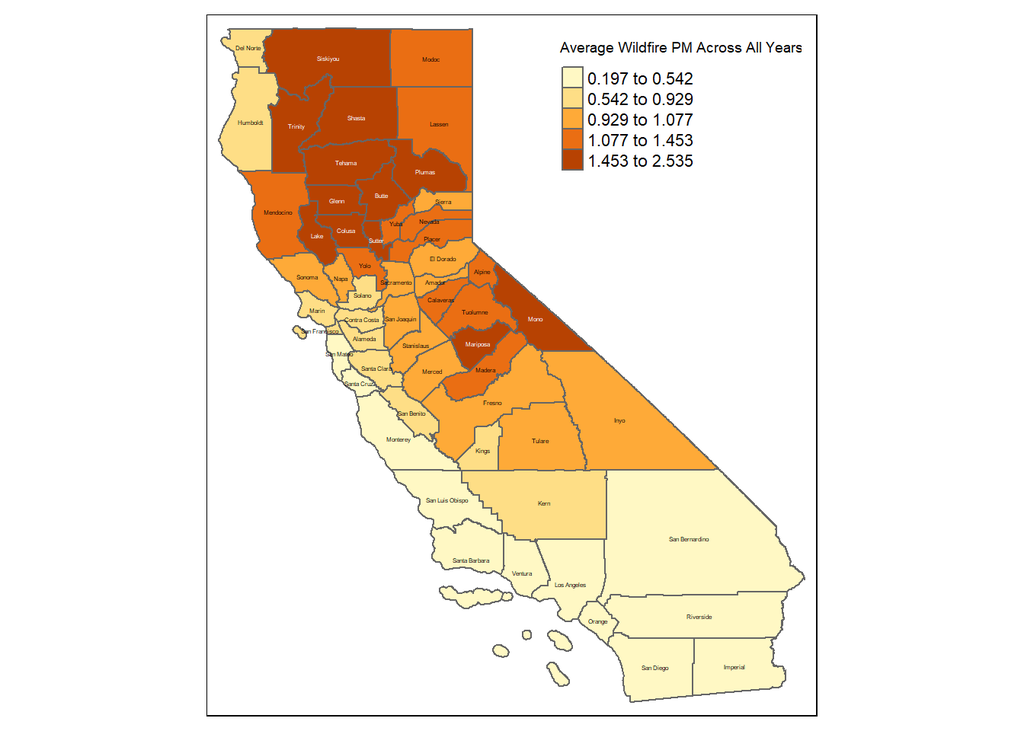

```r
average_pm <- weighted_grids_join %>%
  group_by(county) %>%
  summarize(average_pm = mean(pm25))


county_sf <- average_pm %>%
inner_join(ca_county_geoms, by = "county") %>%
  st_sf()

tm_shape(county_sf) +
  tm_polygons("average_pm",
              style = "quantile",
              title = "Average Wildfire PM Across All Years") +
              tm_text("county", size = 1/4)
```

# Do these counties also have the most days with smoke overhead? Is there a difference between the two?

### Take-aways

- Big differences look like Fresno and Tulare, as well as Imperial on the bottom. Is this downwind smoke?

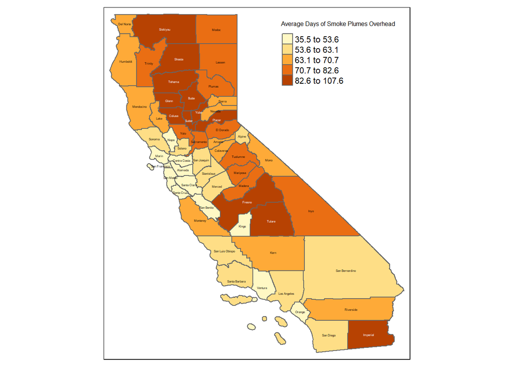

```r
smoke_days_by_year <- unweighted_grids %>%
  group_by(county, year = floor_date(date, "year")) %>%
  summarize(days = n_distinct(date)) %>%
  mutate(year = as.numeric(format(year,'%Y'))) %>%
  select(county, year, days)

smoke_days_average <- smoke_days_by_year %>%
  group_by(county) %>%
  summarize(average_smoke_days = round(mean(days), digits = 2))

smoke_days_sf <- smoke_days_average %>%
inner_join(ca_county_geoms, by = "county") %>%
  st_sf()

tm_shape(smoke_days_sf) +
  tm_polygons("average_smoke_days",
              style = "quantile",
              title = "Average Days of Smoke Plumes Overhead") +
              tm_text("county", size = 1/4)
```

### Data to explore average smoke days (overhead) across all years

```r
datatable(smoke_days_average, filter = 'top', class = 'cell-border stripe order-column', extensions = 'Buttons',

                            options = list(
                                paging = TRUE,
                                searching = TRUE,
                                fixedColumns = TRUE,
                                autoWidth = TRUE,
                                ordering = TRUE,
                                dom = 'tB',
                                buttons = c('copy', 'csv', 'excel')
                            ))
```

|  | county | average_smoke_days |
| --- | --- | --- |
| 1 | Alameda | 45.47 |
| 2 | Alpine | 58.6 |
| 3 | Amador | 64.33 |
| 4 | Butte | 107.6 |
| 5 | Calaveras | 66 |
| 6 | Colusa | 103.2 |
| 7 | Contra Costa | 50.87 |
| 8 | Del Norte | 65.93 |
| 9 | El Dorado | 77.4 |
| 10 | Fresno | 101.47 |

[output cut: 48 more lines]

### Data to explore average smoke days (overhead) in yearly changes

```r
smoke_days_by_year <- unweighted_grids %>%
  group_by(county, year = floor_date(date, "year")) %>%
  summarize(days = n_distinct(date)) %>%
  mutate(year = as.numeric(format(year,'%Y'))) %>%
  select(county, year, days)

smoke_days_by_year_wide <- smoke_days_by_year %>%
  pivot_wider(names_from = year, values_from = days)

datatable(smoke_days_by_year_wide, filter = 'top', class = 'cell-border stripe order-column', extensions = 'Buttons',

                            options = list(
                                paging = TRUE,
                                searching = TRUE,
                                fixedColumns = TRUE,
                                autoWidth = TRUE,
                                ordering = TRUE,
                                dom = 'tB',
                                buttons = c('copy', 'csv', 'excel')
                            ))
```

|  | county | 2006 | 2007 | 2008 | 2009 | 2010 | 2011 | 2012 | 2013 | 2014 | 2015 | 2016 | 2017 | 2018 | 2019 | 2020 |
| --- | --- | --- | --- | --- | --- | --- | --- | --- | --- | --- | --- | --- | --- | --- | --- | --- |
| 1 | Alameda | 47 | 29 | 71 | 29 | 20 | 19 | 22 | 51 | 27 | 37 | 51 | 61 | 80 | 45 | 93 |
| 2 | Alpine | 51 | 52 | 75 | 48 | 35 | 44 | 36 | 74 | 43 | 58 | 53 | 92 | 85 | 42 | 91 |
| 3 | Amador | 49 | 51 | 83 | 56 | 37 | 57 | 37 | 78 | 46 | 62 | 60 | 83 | 99 | 57 | 110 |
| 4 | Butte | 86 | 89 | 116 | 85 | 63 | 95 | 123 | 131 | 115 | 113 | 85 | 109 | 147 | 108 | 149 |
| 5 | Calaveras | 51 | 48 | 85 | 54 | 46 | 58 | 38 | 83 | 45 | 60 | 62 | 91 | 101 | 56 | 112 |
| 6 | Colusa | 83 | 80 | 118 | 76 | 58 | 94 | 114 | 127 | 111 | 112 | 76 | 106 | 147 | 99 | 147 |
| 7 | Contra Costa | 54 | 36 | 78 | 29 | 29 | 27 | 28 | 53 | 34 | 43 | 48 | 68 | 88 | 44 | 104 |
| 8 | Del Norte | 75 | 43 | 109 | 49 | 32 | 30 | 70 | 71 | 67 | 74 | 39 | 93 | 97 | 40 | 100 |
| 9 | El Dorado | 62 | 68 | 89 | 71 | 41 | 58 | 52 | 89 | 63 | 79 | 74 | 85 | 118 | 75 | 137 |
| 10 | Fresno | 72 | 78 | 132 | 72 | 86 | 86 | 63 | 104 | 63 | 92 | 118 | 145 | 146 | 94 | 171 |

[output cut: 48 more lines]

# Which months and were the worst?

### Take-away

- Caveat: this is unweighted, so we won’t be making the claim which days were the “worst for people’s health”
- Top five worst months? August, September, October of 2020 along with August and November of 2018

```r
worst_months <- unweighted_grids %>%
  mutate(date = floor_date(as_date(date), "month")) %>%
  group_by(date) %>%
  summarize(avg_wildfire_pm = round(mean(pm25), digits = 2)) %>%
  mutate(date = format(date, "%B %Y"))

datatable(worst_months, filter = 'top', class = 'cell-border stripe order-column', extensions = 'Buttons',

                            options = list(
                                paging = TRUE,
                                searching = TRUE,
                                fixedColumns = TRUE,
                                autoWidth = TRUE,
                                ordering = TRUE,
                                dom = 'tB',
                                buttons = c('copy', 'csv', 'excel')
                            ))
```

|  | date | avg_wildfire_pm |
| --- | --- | --- |
| 1 | January 2006 | 3.55 |
| 2 | February 2006 | 5.07 |
| 3 | March 2006 | 3.12 |
| 4 | April 2006 | 2.63 |
| 5 | May 2006 | 2.34 |
| 6 | June 2006 | 5.45 |
| 7 | July 2006 | 4.42 |
| 8 | August 2006 | 7.29 |
| 9 | September 2006 | 8.36 |
| 10 | October 2006 | 5.6 |

[output cut: 170 more lines]

# Which days were the worst and where?

### Take-away

- this seems interesting, especially those three very intense days in Mono County. Estimates reach over 300 micrograms for three days in a row. I’m sure Mono is less populated than other areas of the state, but honing on days like these could be a way to turn back to health experts and say - how bad is breathing in that much PM over multiple days? How dangerous is for people with asthma or other respiratory diseas?

```r
worst_days <- unweighted_grids %>%
  group_by(county, date) %>%
  summarize(avg_wildfire_pm = round(mean(pm25), digits = 2)) %>%
  arrange(desc(avg_wildfire_pm)) %>%
  slice(1:100)

datatable(worst_days, filter = 'top', class = 'cell-border stripe order-column', extensions = 'Buttons',

                            options = list(
                                paging = TRUE,
                                searching = TRUE,
                                fixedColumns = TRUE,
                                autoWidth = TRUE,
                                ordering = TRUE,
                                dom = 'tB',
                                buttons = c('copy', 'csv', 'excel')
                            ))
```

|  | county | date | avg_wildfire_pm |
| --- | --- | --- | --- |
| 1 | Alameda | 2018-11-16 | 123.36 |
| 2 | Alameda | 2018-11-15 | 103.88 |
| 3 | Alameda | 2020-09-11 | 103.26 |
| 4 | Alameda | 2020-09-12 | 92.6 |
| 5 | Alameda | 2018-11-17 | 90.34 |
| 6 | Alameda | 2020-09-13 | 88.57 |
| 7 | Alameda | 2020-09-14 | 88.33 |
| 8 | Alameda | 2020-10-02 | 77.78 |
| 9 | Alameda | 2018-11-10 | 72.58 |
| 10 | Alameda | 2018-11-14 | 67.79 |

[output cut: 5790 more lines]

# How did fall 2020 look by county?

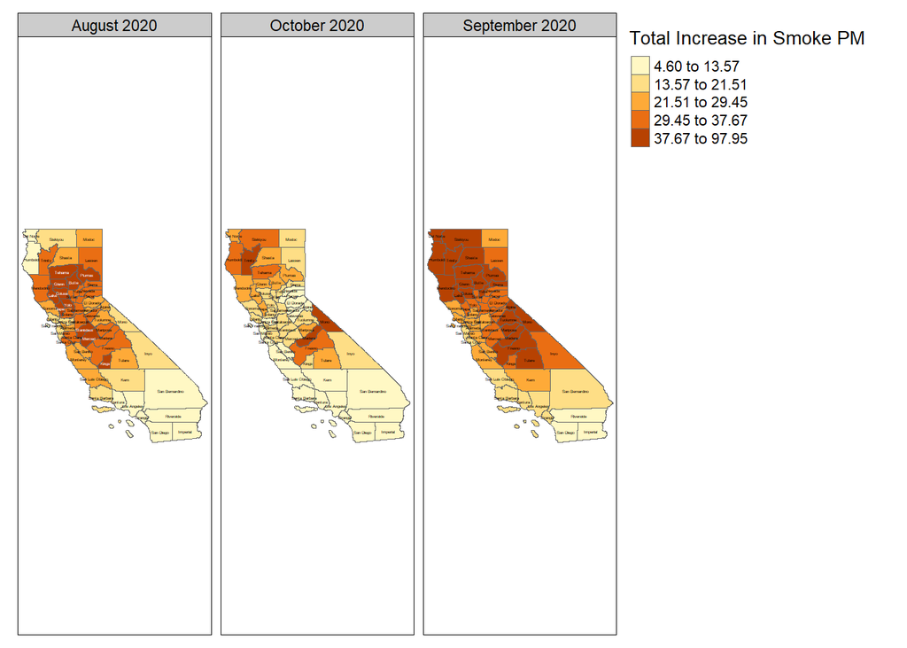

```r
worst_months_by_county <- unweighted_grids %>%
  mutate(date = floor_date(as_date(date), "month")) %>%
  group_by(date, county) %>%
  summarize(avg_wildfire_pm = round(mean(pm25), digits = 2)) %>%
  mutate(date = format(date, "%B %Y"))

fall_2020_sf <- worst_months_by_county %>%
  filter(date %in% c("August 2020", "September 2020", "October 2020")) %>%
  inner_join(ca_county_geoms, by = "county") %>%
  st_sf()

tm_shape(fall_2020_sf) +
  tm_polygons("avg_wildfire_pm",
              style = "quantile",
              title = "Total Increase in Smoke PM") +
              tm_text("county", size = 1/4) +
              tm_facets("date")
```